# Lab_1_BarOz_Omri_and_Berkovich_Maayan

Omri bar oz, Maayan berkovich

4/30/2020

```r
library(ggplot2)
library(tidyr)
library(dslabs)
library(tidyverse)
library(data.table)
library(reshape)
library(dplyr)
```

#Question 1

```r
confirmed_data <- read.csv(url("https://data.humdata.org/hxlproxy/data/download/time_series_covid19_confirmed_global_narrow.csv?dest=data_edit&filter01=merge&merge-url01=https%3A%2F%2Fdocs.google.com%2Fspreadsheets%2Fd%2Fe%2F2PACX-1vTglKQRXpkKSErDiWG6ycqEth32MY0reMuVGhaslImLjfuLU0EUgyyu2e-3vKDArjqGX7dXEBV8FJ4f%2Fpub%3Fgid%3D1326629740%26single%3Dtrue%26output%3Dcsv&merge-keys01=%23country%2Bname&merge-tags01=%23country%2Bcode%2C%23region%2Bmain%2Bcode%2C%23region%2Bsub%2Bcode%2C%23region%2Bintermediate%2Bcode&filter02=merge&merge-url02=https%3A%2F%2Fdocs.google.com%2Fspreadsheets%2Fd%2Fe%2F2PACX-1vTglKQRXpkKSErDiWG6ycqEth32MY0reMuVGhaslImLjfuLU0EUgyyu2e-3vKDArjqGX7dXEBV8FJ4f%2Fpub%3Fgid%3D398158223%26single%3Dtrue%26output%3Dcsv&merge-keys02=%23adm1%2Bname&merge-tags02=%23country%2Bcode%2C%23region%2Bmain%2Bcode%2C%23region%2Bsub%2Bcode%2C%23region%2Bintermediate%2Bcode&merge-replace02=on&merge-overwrite02=on&filter03=explode&explode-header-att03=date&explode-value-att03=value&filter04=rename&rename-oldtag04=%23affected%2Bdate&rename-newtag04=%23date&rename-header04=Date&filter05=rename&rename-oldtag05=%23affected%2Bvalue&rename-newtag05=%23affected%2Binfected%2Bvalue%2Bnum&rename-header05=Value&filter06=clean&clean-date-tags06=%23date&filter07=sort&sort-tags07=%23date&sort-reverse07=on&filter08=sort&sort-tags08=%23country%2Bname%2C%23adm1%2Bname&tagger-match-all=on&tagger-default-tag=%23affected%2Blabel&tagger-01-header=province%2Fstate&tagger-01-tag=%23adm1%2Bname&tagger-02-header=country%2Fregion&tagger-02-tag=%23country%2Bname&tagger-03-header=lat&tagger-03-tag=%23geo%2Blat&tagger-04-header=long&tagger-04-tag=%23geo%2Blon&header-row=1&url=https%3A%2F%2Fraw.githubusercontent.com%2FCSSEGISandData%2FCOVID-19%2Fmaster%2Fcsse_covid_19_data%2Fcsse_covid_19_time_series%2Ftime_series_covid19_confirmed_global.csv"),comment.char = '#')

death_data <-read.csv(url("https://data.humdata.org/hxlproxy/data/download/time_series_covid19_deaths_global_narrow.csv?dest=data_edit&filter01=merge&merge-url01=https%3A%2F%2Fdocs.google.com%2Fspreadsheets%2Fd%2Fe%2F2PACX-1vTglKQRXpkKSErDiWG6ycqEth32MY0reMuVGhaslImLjfuLU0EUgyyu2e-3vKDArjqGX7dXEBV8FJ4f%2Fpub%3Fgid%3D1326629740%26single%3Dtrue%26output%3Dcsv&merge-keys01=%23country%2Bname&merge-tags01=%23country%2Bcode%2C%23region%2Bmain%2Bcode%2C%23region%2Bsub%2Bcode%2C%23region%2Bintermediate%2Bcode&filter02=merge&merge-url02=https%3A%2F%2Fdocs.google.com%2Fspreadsheets%2Fd%2Fe%2F2PACX-1vTglKQRXpkKSErDiWG6ycqEth32MY0reMuVGhaslImLjfuLU0EUgyyu2e-3vKDArjqGX7dXEBV8FJ4f%2Fpub%3Fgid%3D398158223%26single%3Dtrue%26output%3Dcsv&merge-keys02=%23adm1%2Bname&merge-tags02=%23country%2Bcode%2C%23region%2Bmain%2Bcode%2C%23region%2Bsub%2Bcode%2C%23region%2Bintermediate%2Bcode&merge-replace02=on&merge-overwrite02=on&filter03=explode&explode-header-att03=date&explode-value-att03=value&filter04=rename&rename-oldtag04=%23affected%2Bdate&rename-newtag04=%23date&rename-header04=Date&filter05=rename&rename-oldtag05=%23affected%2Bvalue&rename-newtag05=%23affected%2Binfected%2Bvalue%2Bnum&rename-header05=Value&filter06=clean&clean-date-tags06=%23date&filter07=sort&sort-tags07=%23date&sort-reverse07=on&filter08=sort&sort-tags08=%23country%2Bname%2C%23adm1%2Bname&tagger-match-all=on&tagger-default-tag=%23affected%2Blabel&tagger-01-header=province%2Fstate&tagger-01-tag=%23adm1%2Bname&tagger-02-header=country%2Fregion&tagger-02-tag=%23country%2Bname&tagger-03-header=lat&tagger-03-tag=%23geo%2Blat&tagger-04-header=long&tagger-04-tag=%23geo%2Blon&header-row=1&url=https%3A%2F%2Fraw.githubusercontent.com%2FCSSEGISandData%2FCOVID-19%2Fmaster%2Fcsse_covid_19_data%2Fcsse_covid_19_time_series%2Ftime_series_covid19_deaths_global.csv"),comment.char = '#')

recovered_data <- read.csv(url("https://data.humdata.org/hxlproxy/data/download/time_series_covid19_recovered_global_narrow.csv?dest=data_edit&filter01=merge&merge-url01=https%3A%2F%2Fdocs.google.com%2Fspreadsheets%2Fd%2Fe%2F2PACX-1vTglKQRXpkKSErDiWG6ycqEth32MY0reMuVGhaslImLjfuLU0EUgyyu2e-3vKDArjqGX7dXEBV8FJ4f%2Fpub%3Fgid%3D1326629740%26single%3Dtrue%26output%3Dcsv&merge-keys01=%23country%2Bname&merge-tags01=%23country%2Bcode%2C%23region%2Bmain%2Bcode%2C%23region%2Bsub%2Bcode%2C%23region%2Bintermediate%2Bcode&filter02=merge&merge-url02=https%3A%2F%2Fdocs.google.com%2Fspreadsheets%2Fd%2Fe%2F2PACX-1vTglKQRXpkKSErDiWG6ycqEth32MY0reMuVGhaslImLjfuLU0EUgyyu2e-3vKDArjqGX7dXEBV8FJ4f%2Fpub%3Fgid%3D398158223%26single%3Dtrue%26output%3Dcsv&merge-keys02=%23adm1%2Bname&merge-tags02=%23country%2Bcode%2C%23region%2Bmain%2Bcode%2C%23region%2Bsub%2Bcode%2C%23region%2Bintermediate%2Bcode&merge-replace02=on&merge-overwrite02=on&filter03=explode&explode-header-att03=date&explode-value-att03=value&filter04=rename&rename-oldtag04=%23affected%2Bdate&rename-newtag04=%23date&rename-header04=Date&filter05=rename&rename-oldtag05=%23affected%2Bvalue&rename-newtag05=%23affected%2Binfected%2Bvalue%2Bnum&rename-header05=Value&filter06=clean&clean-date-tags06=%23date&filter07=sort&sort-tags07=%23date&sort-reverse07=on&filter08=sort&sort-tags08=%23country%2Bname%2C%23adm1%2Bname&tagger-match-all=on&tagger-default-tag=%23affected%2Blabel&tagger-01-header=province%2Fstate&tagger-01-tag=%23adm1%2Bname&tagger-02-header=country%2Fregion&tagger-02-tag=%23country%2Bname&tagger-03-header=lat&tagger-03-tag=%23geo%2Blat&tagger-04-header=long&tagger-04-tag=%23geo%2Blon&header-row=1&url=https%3A%2F%2Fraw.githubusercontent.com%2FCSSEGISandData%2FCOVID-19%2Fmaster%2Fcsse_covid_19_data%2Fcsse_covid_19_time_series%2Ftime_series_covid19_recovered_global.csv"),comment.char = '#')

recovered_data$Date <- as.Date(recovered_data$Date, "%Y-%m-%d")
death_data$Date <- as.Date(death_data$Date, "%Y-%m-%d")
confirmed_data$Date <- as.Date(confirmed_data$Date, "%Y-%m-%d")
```

```r
cases.agg <- setNames(aggregate(cbind(as.numeric(as.character(Value))) ~ Country.Region + Date, data = confirmed_data, FUN = sum), c("Country.Region", "Date", "Total"))
deaths.agg <- setNames(aggregate(cbind(as.numeric(as.character(Value))) ~ Country.Region + Date, data = death_data, FUN = sum), c("Country.Region", "Date", "Total"))
recovered.agg <- setNames(aggregate(cbind(as.numeric(as.character(Value))) ~ Country.Region + Date, data = recovered_data, FUN = sum), c("Country.Region", "Date", "Total"))
```

```r
cases_pipe <- confirmed_data %>% group_by(Country.Region, Date)  %>% summarize(Total = sum(as.numeric(as.character(Value)))) %>% arrange(Date)

deaths_pipe <- death_data %>% group_by(Country.Region, Date)  %>% summarize(Total = sum(as.numeric(as.character(Value)))) %>% arrange(Date)

recovered_pipe <- recovered_data %>% group_by(Country.Region, Date)  %>% summarize(Total = sum(as.numeric(as.character(Value)))) %>% arrange(Date)

cases_pipe <- cases_pipe[-c(nrow(cases_pipe)),]
deaths_pipe <- deaths_pipe[-c(nrow(deaths_pipe)),]
recovered_pipe <- recovered_pipe[-c(nrow(recovered_pipe)),]
```

```r
last_march_cases <- subset(cases.agg, subset = cases.agg$Date == "2020-03-31")
last_march_cases <- last_march_cases[order(last_march_cases$Total),] # sorts
last_march_death <- subset(deaths.agg, subset = deaths.agg$Date == "2020-03-31")
last_march_recovered <- subset(recovered.agg, subset = recovered.agg$Date == "2020-03-31")
top_10_cases <- tail(last_march_cases, n = 10)
top_10_deaths <- c()
top_10_recovered <- c()
for(country in top_10_cases$Country.Region){
  top_10_deaths <- rbind(top_10_deaths, last_march_death[which(last_march_death$Country.Region == country),])
  top_10_recovered <- rbind(top_10_recovered, last_march_recovered[which(last_march_recovered$Country.Region == country),])
}
```

##### The above block gets the last day of march data, sorts it and then extracts the top 10 countries.

```r
allthedata <- data.frame(Name = top_10_cases$Country.Region, sick = top_10_cases$Total - top_10_recovered$Total - top_10_deaths$Total, death = top_10_deaths$Total, recovered = top_10_recovered$Total)
```

##### The above block creates a new data frame.

```r
transed <- t(allthedata)
# In order to be in the proper format for a barplot, We had to transpose the data from long to wide.
```

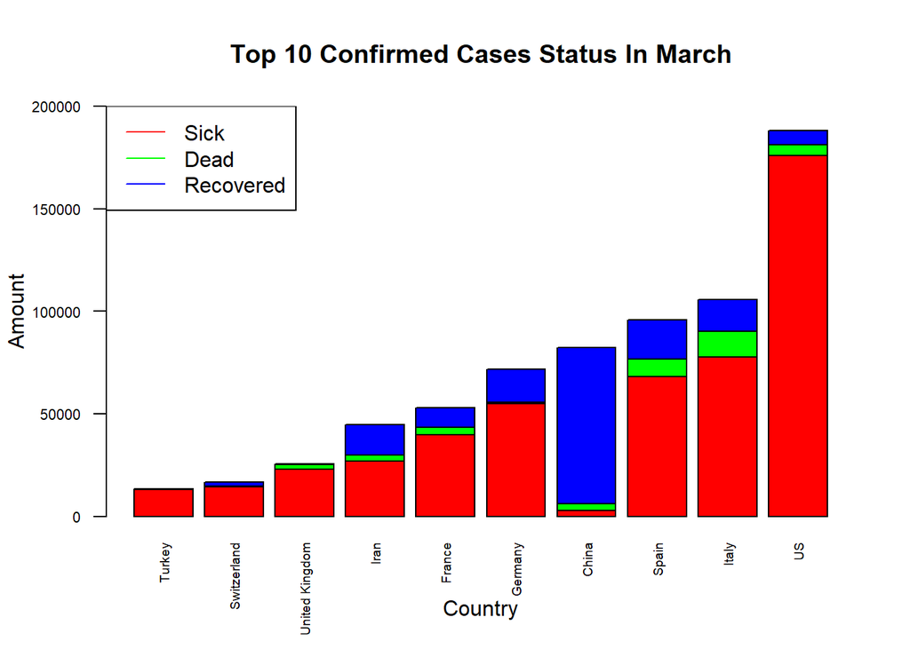

```r
p <- barplot(rbind(transed[2,],transed[3,],transed[4,]), names.arg = transed[1,], main = "Top 10 Confirmed Cases Status In March",
             xlab = "Country", ylab = "Amount", ylim = c(0,200000),cex.names = 0.6 ,cex.axis = 0.7,
             col = c("red","green","blue"),las=2)
legend(x = "topleft", col = c("red", "green","blue"), lty=1, lwd=1,legend = c("Sick", "Dead", "Recovered"))
```

##### The biggest issue with the plot is that the data isn’t normalized. It is not relative, obviously higher pop countries will have more sick and dead.

#Question 2

```r
diff <- c(0)
cases.agg <- cbind(cases.agg, diff) #Adds the column diff to the table cases.agg
cases.agg$diff <- as.integer(cases.agg$diff)
cases.agg <- cases.agg[order(cases.agg$Country.Region),] #We will arrange our list by country names

# The function will run on the entire list if the name of the country matches the name that precedes it and it will drop between the two values if we do not sign that we have started a new state and it will start with zero

for (i in 1:(length(cases.agg$Total)-1)){
  if (cases.agg$Country.Region[i+1] == cases.agg$Country.Region[i]){
    cases.agg$diff[i+1] <- (cases.agg$Total[i+1]-cases.agg$Total[i])
  }else{cases.agg$diff[i+1] <- 0}
}

# We'll do the same process on the table deaths.agg

diff <- c(0)
deaths.agg <- cbind(deaths.agg, diff)
deaths.agg$diff <- as.integer(deaths.agg$diff)
deaths.agg <- deaths.agg[order(deaths.agg$Country.Region),]

for (i in 1:(length(deaths.agg$Total)-1)){
  if (deaths.agg$Country.Region[i+1] == deaths.agg$Country.Region[i]){
    deaths.agg$diff[i+1] <- (deaths.agg$Total[i+1]-deaths.agg$Total[i])
  }else{deaths.agg$diff[i+1] <- 0}
}
```

```r
# The top 10 instances of country and date combinations with the greatest absolute number of new daily Corona cases and deaths
cases.agg <- cases.agg[order(cases.agg$diff),] # sort by the value of diff
tail(cases.agg,10) # We will select the bottom 10 values
```

```
##       Country.Region       Date  Total  diff
## 15902             US 2020-04-16 667592 31242
## 14422             US 2020-04-08 428654 31533
## 13497             US 2020-04-03 275367 31745
## 16087             US 2020-04-17 699706 32114
## 16272             US 2020-04-18 732197 32491
## 17567             US 2020-04-25 938154 32796
## 13682             US 2020-04-04 308650 33283
## 14792             US 2020-04-10 496535 33755
## 14607             US 2020-04-09 462780 34126
## 17382             US 2020-04-24 905358 36188
```

```r
deaths.agg <- deaths.agg[order(deaths.agg$diff),] # sort by the value of diff
tail(deaths.agg,10) # We will select the bottom 10 values
```

```
##       Country.Region       Date Total diff
## 17567             US 2020-04-25 53755 2262
## 14237             US 2020-04-07 16191 2297
## 17197             US 2020-04-23 49724 2312
## 17012             US 2020-04-22 47412 2326
## 16272             US 2020-04-18 39753 2342
## 15532             US 2020-04-14 30262 2392
## 16827             US 2020-04-21 45086 2427
## 15717             US 2020-04-15 32734 2472
## 16087             US 2020-04-17 37411 2584
## 18307             US 2020-04-29 60967 2612
```

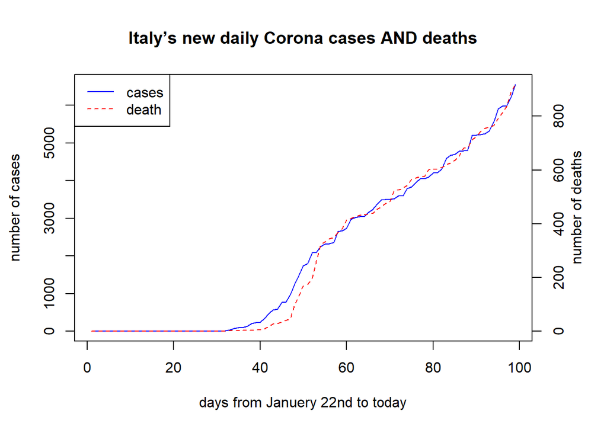

```r
Italy.cases <- cases.agg[which(cases.agg$Country.Region=='Italy'),]
Italy.cases$Date <- as.Date(Italy.cases$Date, "%Y-%m-%d")

Italy.death <- deaths.agg[which(deaths.agg$Country.Region=='Italy'),]
Italy.death$Date <- as.Date(Italy.death$Date, "%Y-%m-%d")


Italy.cases <- cbind(Italy.cases, Italy.death$diff)
Italy.cases.nar <- Italy.cases[c('Date','diff', "Italy.death$diff")]


#Two y axis plot
par(mar = c(5, 4, 4, 4) + 0.3) # Additional space for second y-axis
plot(Italy.cases.nar[1:length(Italy.cases.nar$Date), 2], type ="l", ylab = "number of cases",
     main = "Italy’s new daily Corona cases AND deaths", xlab = "days from Januery 22nd to today",
     col = "blue")

par(new = TRUE)
plot(Italy.cases.nar[,3], type = "l", xaxt = "n", yaxt = "number of deaths", ylab = "", xlab = "", col = "red", lty = 2)
axis(4)

mtext("number of deaths", side = 4, line = 2)

legend("topleft", c("cases", "death"),
       col = c("blue", "red"), lty = c(1, 2))
```

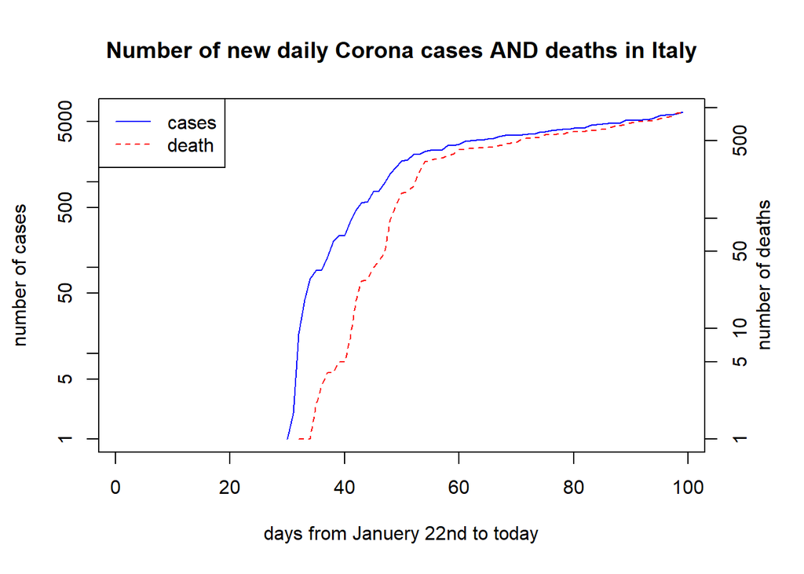

```r
# logarithm scale of Two y axis plot
par(mar = c(5, 4, 4, 4) + 0.3) # Additional space for second y-axis
plot(Italy.cases.nar[1:length(Italy.cases.nar$Date), 2], type ="l", ylab = "number of cases",
     main = "Number of new daily Corona cases AND deaths in Italy", xlab = "days from Januery 22nd to today",
     col = "blue", log='y')
par(new = TRUE)

plot(Italy.cases.nar[,3], type = "l", xaxt = "n", yaxt = "number of deaths", ylab = "", xlab = "", col = "red", lty = 2, log='y')
axis(4)

mtext("number of deaths", side = 4, line = 2)
legend("topleft", c("cases", "death"), col = c("blue", "red"), lty = c(1, 2))
```

# Question 3

```r
eco_data <- read.csv(url("https://raw.githubusercontent.com/DataScienceHU/DataAnalysisR_2020/master/data/economic_data.csv"))

colnames(eco_data) <- c("country","S_country","feature","feature_code","Y2018V","Y2019V")
pure <- data.frame(country = eco_data$country, feature = eco_data$feature, Y2018V = eco_data$Y2018V)
```

```r
eco <- reshape(data=pure, idvar="country", timevar = unique("feature"), direction = "wide")
```

```
## Warning in reshapeWide(data, idvar = idvar, timevar = timevar, varying =
## varying, : multiple rows match for feature=: first taken
```

```r
eco <- eco[-c(267,266,265),] # removes last rows
eco <- eco[,-12] # removes last column
colnames(eco)<-c("country", as.character(pure$feature[1:10]))
print(head(eco))
```

```
##           country GDP (current US$) GDP (constant LCU)
## 1     Afghanistan  19362969582.3643   511432475534.156
## 11        Albania   15102500898.238      1513259270000
## 21        Algeria   173757952824.25   6123376375970.86
## 31 American Samoa         636000000          608000000
## 41        Andorra  3236543909.34844         2002840000
## 51         Angola   105750987618.63      1552771000000
##    GDP, PPP (current international $)
## 1                    72672245387.0863
## 11                   38306694289.2319
## 21                   653771569286.319
## 31                                 ..
## 41                                 ..
## 51                   198795526982.065
##    Unemployment, female (% of female labor force) (modeled ILO estimate)
```

[output cut: 41 more lines]

#### We had to reshape the data so we had a column of countries, and our features were the rest of the columns. again, from long to wide. The warning here is due to the fact there are more features then columns. but, because of repition its okay.

```r
colnames(eco)[2] <- "GDP"
colnames(eco)[11] <- "pop_65"
colnames(eco)[9] <- "pop_city_ratio"
colnames(eco)[8] <- "pop_total"
```

```r
eco$GDP_PER_CAPITA <- as.numeric(as.character(eco$GDP)) / as.numeric(as.character(eco$pop_total)) # The calculation. Important to note the use of as.numeric(as.character()) - the data is read as factors, and this is the way to overcome this. numeric factors do not give the actual integer value in the data.
```

```
## Warning: NAs introduced by coercion

## Warning: NAs introduced by coercion
```

```r
eco <- eco[order(eco$GDP_PER_CAPITA),] # sorts
top_ind <- which(eco$GDP_PER_CAPITA==max(eco$GDP_PER_CAPITA, na.rm = TRUE)) # gets the max value, ignores NA
top_5_table <- eco[(top_ind-4):top_ind,] # slices them - we want the top 5
# there are 264 countries, taking down 10%  so 26 are out.
print(top_5_table)
```

```
##               country              GDP GDP (constant LCU)
## 1471           Norway 434166615431.909      3259053000000
## 1881      Switzerland 705140354166.312       696139480200
## 1171 Macao SAR, China 55084050789.7182       429497000000
## 1161       Luxembourg 70885325883.0941        57152595000
## 1301           Monaco 7184844192.63456   5720647180.37038
##      GDP, PPP (current international $)
## 1471                   348145261704.001
## 1881                   579643931032.338
## 1171                   78254752438.0468
## 1161                   68878323882.4048
## 1301                                 ..
##      Unemployment, female (% of female labor force) (modeled ILO estimate)
## 1471                                                      3.49499988555908
## 1881                                                      5.15500020980835
```

[output cut: 33 more lines]

```r
eco <- eco[-c(seq(1,26)),]
x <- as.numeric(as.character(eco$pop_65))
```

```
## Warning: NAs introduced by coercion
```

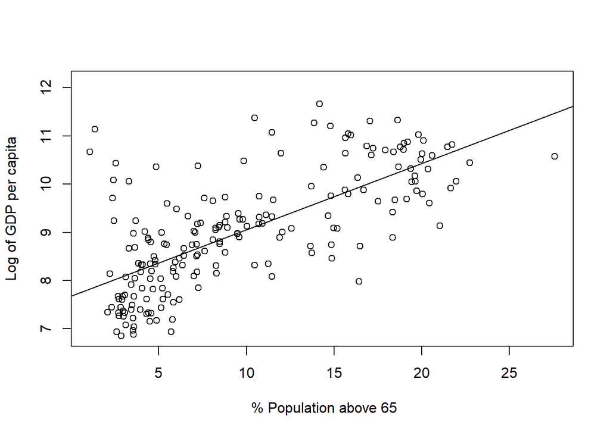

```r
y <- log(eco$GDP_PER_CAPITA)
plot(x, y, xlab= " % Population above 65", ylab = "Log of GDP per capita")
rgr <- lm(y ~ x)
abline(rgr)
```

### Plot + RGR shows two things - firstly, not a lot of countries have high percentages of pop 65. secondly, the higher the pop_65, the higher the gdp. So, a country that is ‘younger’ will have less GDP. we persume this is because elderly people tend to have better careers and much more experience, so, higher salaries. Warnings are due to numeric conversion of null values. This is okay.

#Question 4

```r
cases.agg$Date <- as.Date(cases.agg$Date, "%Y-%m-%d")
recovered.agg$Date <- as.Date(recovered.agg$Date, "%Y-%m-%d")
deaths.agg$Date <- as.Date(deaths.agg$Date, "%Y-%m-%d")
# sorts
cases.agg <- cases.agg[order(cases.agg$Date),]
recovered.agg <- recovered.agg[order(recovered.agg$Date),]
deaths.agg <- deaths.agg[order(deaths.agg$Date),]

cases.agg <- cases.agg[order(cases.agg$Country.Region),]
recovered.agg <- recovered.agg[order(recovered.agg$Country.Region),]
deaths.agg <- deaths.agg[order(deaths.agg$Country.Region),]

corona <- cbind(cases.agg ,country = cases.agg$Country.Region, Date = cases.agg$Date, cases_val = cases.agg$Total, cases_diff = cases.agg$diff, recovered_val = recovered.agg$Total, deaths_val = deaths.agg$Total, deaths_dif = deaths.agg$diff )

corona <- corona[,-c(1,2,3,4)] # removes first columns

#full join
ecorona <- merge(corona,eco,by="country")
ecorona <- ecorona[,-c(4, 7, 9, 10, 11, 12, 13, 16, 18)]
ecorona
```

[output not shown]

[output cut: 22210 more lines]

```r
cases_normal <- c(0)
deaths_normal <- c(0)
recovered_normal <- c(0)

#Adds the new columns to the table ecorona
ecorona <- cbind(ecorona, cases_normal)
ecorona <- cbind(ecorona, deaths_normal)
ecorona <- cbind(ecorona, recovered_normal)

ecorona$cases_normal <- as.numeric(as.character(ecorona$cases_normal))
ecorona$deaths_normal <- as.numeric(as.character(ecorona$deaths_normal))
ecorona$recovered_normal <- as.numeric(as.character(ecorona$recovered_normal))
ecorona$pop_total <-  as.numeric(as.character(ecorona$pop_total))
# The function runs over the total population and calculates the normalization for each

for (i in 1:(length(ecorona$pop_total))){
  ecorona$cases_normal[i] <- ((ecorona$cases_val[i])/(ecorona$pop_total[i]/100000))

  ecorona$deaths_normal[i] <- ((ecorona$deaths_val[i])/(ecorona$pop_total[i]/100000))

  ecorona$recovered_normal[i] <- ((ecorona$recovered_val[i])/(ecorona$pop_total[i]/100000))
}
```

```r
Marchecorona_cases <- subset(ecorona, subset = ecorona$Date == "2020-03-31")
Marchecorona_cases <- Marchecorona_cases[order(-Marchecorona_cases$cases_normal),] # sorts
Marchecorona_top10 <- head(Marchecorona_cases, 10)
Marchecorona_top10
```

```
##             country       Date cases_val recovered_val deaths_val
## 10674    San Marino 2020-03-31       236            13         26
## 229         Andorra 2020-03-31       376            10         12
## 7530     Luxembourg 2020-03-31      2178            80         23
## 5650        Iceland 2020-03-31      1135           198          2
## 11621         Spain 2020-03-31     95923         19259       8464
## 12173   Switzerland 2020-03-31     16605          1823        433
## 7421  Liechtenstein 2020-03-31        68             0          0
## 6263          Italy 2020-03-31    105792         15729      12428
## 8361         Monaco 2020-03-31        52             2          1
## 809         Austria 2020-03-31     10180          1095        128
##                    GDP pop_total   pop_city_ratio           pop_65 cases_normal
## 10674               ..     33785               ..               ..     698.5349
## 229   3236543909.34844     77006               ..               ..     488.2736
## 7530  70885325883.0941    607728               .. 14.1831541841472     358.3840
```

[output cut: 18 more lines]

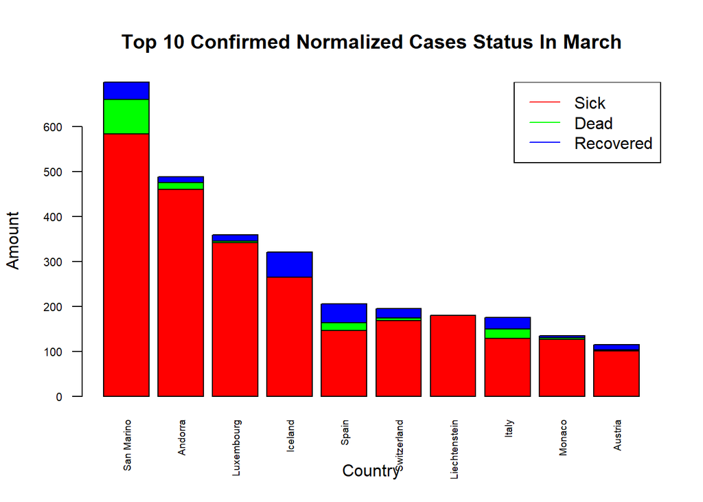

```r
allthedata_normal <- data.frame(country = Marchecorona_top10$country,
                                sick= Marchecorona_top10$cases_normal - Marchecorona_top10$deaths_normal - Marchecorona_top10$recovered_normal,
                                deaths = Marchecorona_top10$deaths_normal,
                                recovered = Marchecorona_top10$recovered_normal)



transed_normal <- t(allthedata_normal)

p <- barplot(rbind(transed_normal[2,],transed_normal[3,],transed_normal[4,]), names.arg = transed_normal[1,], main = "Top 10 Confirmed Normalized Cases Status In March",
             xlab = "Country", ylab = "Amount",cex.names = 0.6 ,cex.axis = 0.7,
             col = c("red","green","blue"),las=2)
legend(x = "topright", col = c("red", "green","blue"), lty=1, lwd=1,legend = c("Sick", "Dead", "Recovered"))
```

### The graph from the first question shows how many cases have so far been diagnosed (including cases that have already ended as a result of death or recovery) in each country. The larger the population of a country, the greater the number of cases (and the number of the dead and the healed) expected to be. However, this is not a good indication of the true state of the world because a larger country has more space where patients are spread out on and more hospitals and is able to withstand a larger amount of patients at once. In order to compare the situation in different countries, we must normalize the number cases per capita (in our case per 100k citizens). So we can see, for example, that even though the US has a much larger number of cases than San Marino, the normalized numbers show that the US situation is much better than the situation in San Marino. This is because US patients are mainly concentrated in New York and in a few other states and other states can support New York through sending medical equipment and doctors. By contrast, San Marino is a smaller state with a smaller number of medical centers that can support a smaller number of Patients.

```r
Marchecorona65 <- subset(ecorona, subset = ecorona$Date == "2020-03-31")
Marchecorona65$pop_65 <-  as.numeric(as.character(Marchecorona65$pop_65))
```

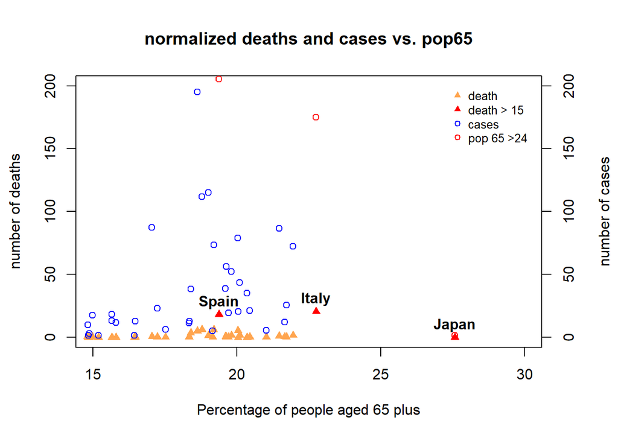

```r
Marchecorona65$country <- as.character(Marchecorona65$country)
# plot
par(mar = c(5, 4, 4, 4) + 0.3) # Additional space for second y-axis

plot(Marchecorona65$pop_65, Marchecorona65$deaths_normal, main="normalized deaths and cases vs. pop65", xlab = "Percentage of people aged 65 plus", ylab = "number of deaths", xlim = c(15,30), ylim = c(0,200), col=ifelse(((abs(Marchecorona65$pop_65)>24 | abs(Marchecorona65$deaths_normal)>15)),"red", "tan1"),pch=17) # Create first plot

par(new = TRUE) # Add new plot
plot(Marchecorona65$pop_65, Marchecorona65$cases_normal, xlim = c(15,30), ylim = c(0,200), col=ifelse(((abs(Marchecorona65$pop_65)>24 | abs(Marchecorona65$deaths_normal)>15)),"red", "blue"),
,pch=1, # Create second plot without axes
     axes = FALSE, xlab = "", ylab = "")
axis(4)
axis(side = 4, at = pretty(range(Marchecorona65$cases_normal))) # Add second axis
mtext("number of cases", side = 4, line = 3)

# Add a legend
legend("topright",inset= 0.02, c("death", "death > 15", "cases", "pop 65 >24"),col = c( "tan1","red","blue", "red"), pch = c(17,17,1, 1), cex=0.8,box.lty=0)

text(x=Marchecorona65$pop_65, font=2, y=Marchecorona65$deaths_normal + 10, labels=ifelse((Marchecorona65$pop_65 > 24) |(Marchecorona65$deaths_normal > 15), Marchecorona65$country, NA))
```

# Question 5

```r
tests <- read.csv(url("https://raw.githubusercontent.com/DataScienceHU/52414-lab-1-baroz_omri_and_berkovich_maayan/master/full-list-total-tests-for-covid-19%20(8).csv"))
```

#### Taken from the same database as the lab, john hopkins.

```r
chosen_countries_data <- rbind(tests[which(tests$Entity=="Zimbabwe"),],
                       tests[which(tests$Entity=="Bolivia"),],
                       tests[which(tests$Entity=="United States"),],
                       tests[which(tests$Entity=="Italy"),],
                       tests[which(tests$Entity=="Israel"),])
colnames(chosen_countries_data)[1] <- "Country.Region"

chosen_countries_tests <- chosen_countries_data[order(chosen_countries_data$Date),]
march_tests <- chosen_countries_tests[which(chosen_countries_tests$Date=="Mar 31, 2020"),]
chosen_countries_cases <- rbind(cases.agg[which(cases.agg$Country.Region=="Zimbabwe"),],
                                cases.agg[which(cases.agg$Country.Region=="Bolivia"),],
                                cases.agg[which(cases.agg$Country.Region=="US"),],
                                cases.agg[which(cases.agg$Country.Region=="Italy"),],
                                cases.agg[which(cases.agg$Country.Region=="Israel"),])
march_cases <- chosen_countries_cases[which(chosen_countries_cases$Date=="2020-03-31"),]

march_cases <- march_cases[,-2]
march_tests <- march_tests[,-c(2,3)]
joint_cases_tests <- rbind(t(march_cases), t(march_tests$Total.tests))

start_tests <- chosen_countries_tests[which(chosen_countries_tests$Date=="Apr 11, 2020"),]
start_cases <- chosen_countries_cases[which(chosen_countries_cases$Date=="2020-04-11"),]

start_cases <- start_cases[,-2]
start_tests <- start_tests[,-c(2,3)]
jointstart_cases_tests <- rbind(t(start_cases), t(start_tests$Total.tests))
```

### We were curious regarding the correlation between number of tests and the number of cases. Our theory was that the more tests -> more cases. We’ve chosen 5 countries, with the US just for curiosity and countries which have similar populations (but diff socio economic capabilities, which affect ability to purchase testing tools). We’ve checked on two separate dates;

[figure not shown]

```r
p <- barplot(rbind(as.numeric(as.character(joint_cases_tests[2,])), as.numeric(as.character(joint_cases_tests[3,]))), names.arg = joint_cases_tests[1,], main = "31st March selected countries cases vs tests", col = c("red", "green"), beside=TRUE)
legend(x = "topleft", col = c("red", "green"), lty=1, lwd=1,legend = c("Tests", "Cases"))
```

[figure not shown]

```r
p <- barplot(rbind(as.numeric(as.character(jointstart_cases_tests[2,])), as.numeric(as.character(jointstart_cases_tests[3,]))), names.arg = jointstart_cases_tests[1,], main = "11th April selected countries cases vs tests", col = c("red","green"), beside=TRUE)
legend(x = "topleft", col = c("red", "green"), lty=1, lwd=1,legend = c("Tests", "Cases"))
```